# Risk Factor Analysis

## Outcome Variable

**Outcome Variable:** ever_swasted

## Predictor Variables

**Intervention Variable:** fhtcm

**Adjustment Set:**

- arm
- W_mage
- W_fage
- meducyrs
- feducyrs
- W_mhtcm
- W_mwtkg
- W_mbmi
- single
- delta_W_mage
- delta_W_fage
- delta_meducyrs
- delta_feducyrs
- delta_W_mhtcm
- delta_W_mwtkg
- delta_W_mbmi
- delta_single

## Stratifying Variables

The analysis was stratified on these variable(s):

- agecat
- studyid
- country

## Data Summary

| agecat | studyid | country | fhtcm | ever_swasted | n_cell | n |
| --- | --- | --- | --- | --- | --- | --- |
| 0-24 months | ki1000304b-SAS-CompFeed | INDIA | >=167 cm | 0 | 357 | 895 |
| 0-24 months | ki1000304b-SAS-CompFeed | INDIA | >=167 cm | 1 | 50 | 895 |
| 0-24 months | ki1000304b-SAS-CompFeed | INDIA | <162 cm | 0 | 195 | 895 |
| 0-24 months | ki1000304b-SAS-CompFeed | INDIA | <162 cm | 1 | 31 | 895 |
| 0-24 months | ki1000304b-SAS-CompFeed | INDIA | [162-167) cm | 0 | 221 | 895 |
| 0-24 months | ki1000304b-SAS-CompFeed | INDIA | [162-167) cm | 1 | 41 | 895 |
| 0-24 months | ki1000304b-SAS-FoodSuppl | INDIA | >=167 cm | 0 | 91 | 399 |
| 0-24 months | ki1000304b-SAS-FoodSuppl | INDIA | >=167 cm | 1 | 15 | 399 |
| 0-24 months | ki1000304b-SAS-FoodSuppl | INDIA | <162 cm | 0 | 131 | 399 |
| 0-24 months | ki1000304b-SAS-FoodSuppl | INDIA | <162 cm | 1 | 32 | 399 |
| 0-24 months | ki1000304b-SAS-FoodSuppl | INDIA | [162-167) cm | 0 | 110 | 399 |
| 0-24 months | ki1000304b-SAS-FoodSuppl | INDIA | [162-167) cm | 1 | 20 | 399 |
| 0-24 months | ki1101329-Keneba | GAMBIA | >=167 cm | 0 | 1012 | 1933 |
| 0-24 months | ki1101329-Keneba | GAMBIA | >=167 cm | 1 | 236 | 1933 |
| 0-24 months | ki1101329-Keneba | GAMBIA | <162 cm | 0 | 99 | 1933 |
| 0-24 months | ki1101329-Keneba | GAMBIA | <162 cm | 1 | 33 | 1933 |
| 0-24 months | ki1101329-Keneba | GAMBIA | [162-167) cm | 0 | 454 | 1933 |
| 0-24 months | ki1101329-Keneba | GAMBIA | [162-167) cm | 1 | 99 | 1933 |
| 0-24 months | ki1119695-PROBIT | BELARUS | >=167 cm | 0 | 10729 | 12537 |
| 0-24 months | ki1119695-PROBIT | BELARUS | >=167 cm | 1 | 1015 | 12537 |
| 0-24 months | ki1119695-PROBIT | BELARUS | <162 cm | 0 | 157 | 12537 |
| 0-24 months | ki1119695-PROBIT | BELARUS | <162 cm | 1 | 11 | 12537 |
| 0-24 months | ki1119695-PROBIT | BELARUS | [162-167) cm | 0 | 576 | 12537 |
| 0-24 months | ki1119695-PROBIT | BELARUS | [162-167) cm | 1 | 49 | 12537 |
| 0-24 months | ki1135781-COHORTS | GUATEMALA | >=167 cm | 0 | 61 | 495 |
| 0-24 months | ki1135781-COHORTS | GUATEMALA | >=167 cm | 1 | 2 | 495 |
| 0-24 months | ki1135781-COHORTS | GUATEMALA | <162 cm | 0 | 273 | 495 |
| 0-24 months | ki1135781-COHORTS | GUATEMALA | <162 cm | 1 | 20 | 495 |
| 0-24 months | ki1135781-COHORTS | GUATEMALA | [162-167) cm | 0 | 130 | 495 |
| 0-24 months | ki1135781-COHORTS | GUATEMALA | [162-167) cm | 1 | 9 | 495 |

[output cut: 60 more lines]

The following strata were considered:

- agecat: 0-24 months, studyid: ki1000304b-SAS-CompFeed, country: INDIA
- agecat: 0-24 months, studyid: ki1000304b-SAS-FoodSuppl, country: INDIA
- agecat: 0-24 months, studyid: ki1101329-Keneba, country: GAMBIA
- agecat: 0-24 months, studyid: ki1119695-PROBIT, country: BELARUS
- agecat: 0-24 months, studyid: ki1135781-COHORTS, country: GUATEMALA
- agecat: 0-6 months, studyid: ki1000304b-SAS-CompFeed, country: INDIA
- agecat: 0-6 months, studyid: ki1000304b-SAS-FoodSuppl, country: INDIA
- agecat: 0-6 months, studyid: ki1101329-Keneba, country: GAMBIA
- agecat: 0-6 months, studyid: ki1119695-PROBIT, country: BELARUS
- agecat: 0-6 months, studyid: ki1135781-COHORTS, country: GUATEMALA
- agecat: 6-24 months, studyid: ki1000304b-SAS-CompFeed, country: INDIA
- agecat: 6-24 months, studyid: ki1000304b-SAS-FoodSuppl, country: INDIA
- agecat: 6-24 months, studyid: ki1101329-Keneba, country: GAMBIA
- agecat: 6-24 months, studyid: ki1119695-PROBIT, country: BELARUS
- agecat: 6-24 months, studyid: ki1135781-COHORTS, country: GUATEMALA

### Dropped Strata

Some strata were dropped due to rare outcomes:

- agecat: 0-24 months, studyid: ki1135781-COHORTS, country: GUATEMALA
- agecat: 0-6 months, studyid: ki1000304b-SAS-FoodSuppl, country: INDIA
- agecat: 0-6 months, studyid: ki1135781-COHORTS, country: GUATEMALA
- agecat: 6-24 months, studyid: ki1119695-PROBIT, country: BELARUS
- agecat: 6-24 months, studyid: ki1135781-COHORTS, country: GUATEMALA

## Methods Detail

We’re interested in the causal parameters $E[Y_a]$ for all values of $a \in \mathcal{A}$. These parameters represent the mean outcome if, possibly contrary to fact, we intervened to set all units to have $A=a$. Under the randomization and positivity assumptions, these are identified by the statistical parameters $\psi_a=E_W[E_{Y|A,W}(Y|A=a,W)]$. In addition, we’re interested in the mean of $Y$, $E[Y]$ under no intervention (the observed mean). We will estimate these parameters by using SuperLearner to fit the relevant likelihood factors – $E_{Y|A,W}(Y|A=a,W)$ and $p(A=a|W)$, and then updating our likelihood fit using a joint TMLE.

For unadjusted analyses ($W=\{\}$), initial likelihoods were estimated using Lrnr_glm to estimate the simple $E(Y|A)$ and Lrnr_mean to estimate $p(A)$. For adjusted analyses, a small library containing Lrnr_glmnet, Lrnr_xgboost, and Lrnr_mean was used.

Having estimated these parameters, we will then use the delta method to estimate relative risks and attributable risks relative to a prespecified baseline level of $A$.

# Results Detail

## Results Plots

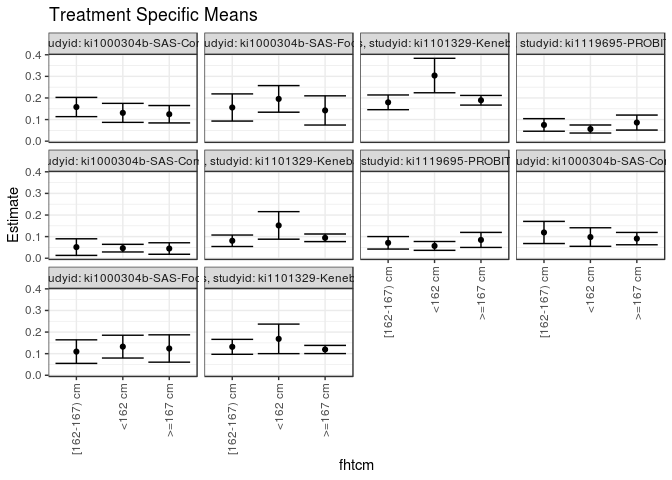

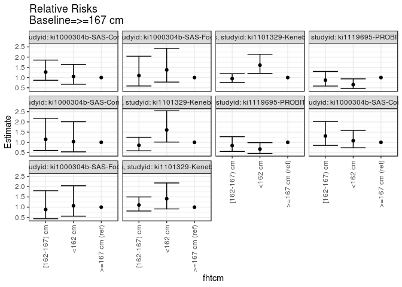

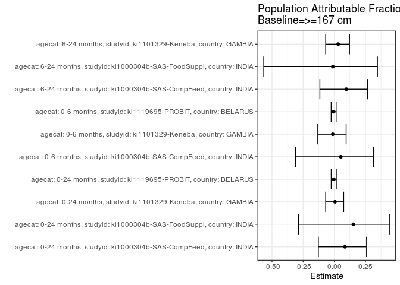

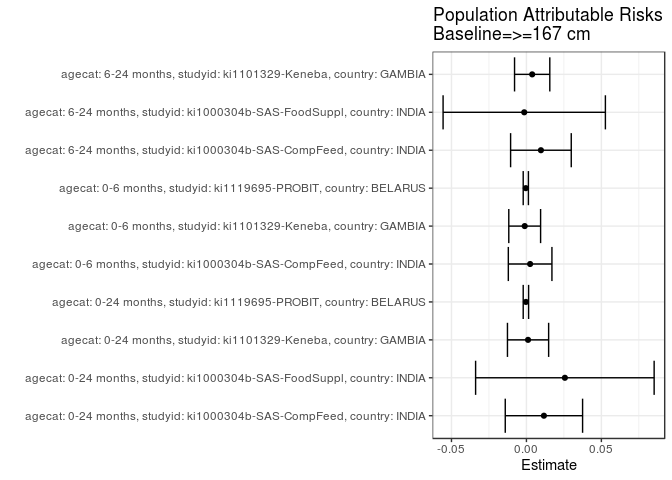

## Results Table

### Parameter: TSM

| agecat | studyid | country | intervention_level | baseline_level | estimate | ci_lower | ci_upper |
| --- | --- | --- | --- | --- | --- | --- | --- |
| 0-24 months | ki1000304b-SAS-CompFeed | INDIA | >=167 cm | NA | 0.1246407 | 0.0843818 | 0.1648995 |
| 0-24 months | ki1000304b-SAS-CompFeed | INDIA | <162 cm | NA | 0.1310202 | 0.0870888 | 0.1749515 |
| 0-24 months | ki1000304b-SAS-CompFeed | INDIA | [162-167) cm | NA | 0.1580584 | 0.1135048 | 0.2026121 |
| 0-24 months | ki1000304b-SAS-FoodSuppl | INDIA | >=167 cm | NA | 0.1422694 | 0.0746333 | 0.2099056 |
| 0-24 months | ki1000304b-SAS-FoodSuppl | INDIA | <162 cm | NA | 0.1956348 | 0.1340722 | 0.2571973 |
| 0-24 months | ki1000304b-SAS-FoodSuppl | INDIA | [162-167) cm | NA | 0.1558722 | 0.0929984 | 0.2187461 |
| 0-24 months | ki1101329-Keneba | GAMBIA | >=167 cm | NA | 0.1892944 | 0.1669311 | 0.2116578 |
| 0-24 months | ki1101329-Keneba | GAMBIA | <162 cm | NA | 0.3038085 | 0.2240406 | 0.3835763 |
| 0-24 months | ki1101329-Keneba | GAMBIA | [162-167) cm | NA | 0.1796973 | 0.1456249 | 0.2137696 |
| 0-24 months | ki1119695-PROBIT | BELARUS | >=167 cm | NA | 0.0860923 | 0.0513495 | 0.1208351 |
| 0-24 months | ki1119695-PROBIT | BELARUS | <162 cm | NA | 0.0561978 | 0.0375804 | 0.0748153 |
| 0-24 months | ki1119695-PROBIT | BELARUS | [162-167) cm | NA | 0.0750198 | 0.0458600 | 0.1041797 |
| 0-6 months | ki1000304b-SAS-CompFeed | INDIA | >=167 cm | NA | 0.0448272 | 0.0182166 | 0.0714378 |
| 0-6 months | ki1000304b-SAS-CompFeed | INDIA | <162 cm | NA | 0.0465530 | 0.0288621 | 0.0642440 |
| 0-6 months | ki1000304b-SAS-CompFeed | INDIA | [162-167) cm | NA | 0.0514119 | 0.0129676 | 0.0898562 |
| 0-6 months | ki1101329-Keneba | GAMBIA | >=167 cm | NA | 0.0944885 | 0.0768561 | 0.1121210 |
| 0-6 months | ki1101329-Keneba | GAMBIA | <162 cm | NA | 0.1517745 | 0.0879994 | 0.2155496 |
| 0-6 months | ki1101329-Keneba | GAMBIA | [162-167) cm | NA | 0.0808168 | 0.0542315 | 0.1074022 |
| 0-6 months | ki1119695-PROBIT | BELARUS | >=167 cm | NA | 0.0846414 | 0.0498049 | 0.1194778 |
| 0-6 months | ki1119695-PROBIT | BELARUS | <162 cm | NA | 0.0568752 | 0.0364396 | 0.0773108 |
| 0-6 months | ki1119695-PROBIT | BELARUS | [162-167) cm | NA | 0.0713003 | 0.0423690 | 0.1002315 |
| 6-24 months | ki1000304b-SAS-CompFeed | INDIA | >=167 cm | NA | 0.0908030 | 0.0623014 | 0.1193047 |
| 6-24 months | ki1000304b-SAS-CompFeed | INDIA | <162 cm | NA | 0.0979275 | 0.0549600 | 0.1408950 |
| 6-24 months | ki1000304b-SAS-CompFeed | INDIA | [162-167) cm | NA | 0.1191685 | 0.0679321 | 0.1704049 |
| 6-24 months | ki1000304b-SAS-FoodSuppl | INDIA | >=167 cm | NA | 0.1239071 | 0.0605531 | 0.1872610 |
| 6-24 months | ki1000304b-SAS-FoodSuppl | INDIA | <162 cm | NA | 0.1325554 | 0.0797117 | 0.1853991 |
| 6-24 months | ki1000304b-SAS-FoodSuppl | INDIA | [162-167) cm | NA | 0.1095092 | 0.0549583 | 0.1640601 |
| 6-24 months | ki1101329-Keneba | GAMBIA | >=167 cm | NA | 0.1193415 | 0.1004780 | 0.1382050 |
| 6-24 months | ki1101329-Keneba | GAMBIA | <162 cm | NA | 0.1685234 | 0.1000752 | 0.2369716 |
| 6-24 months | ki1101329-Keneba | GAMBIA | [162-167) cm | NA | 0.1316744 | 0.0971442 | 0.1662047 |

### Parameter: E(Y)

| agecat | studyid | country | intervention_level | baseline_level | estimate | ci_lower | ci_upper |
| --- | --- | --- | --- | --- | --- | --- | --- |
| 0-24 months | ki1000304b-SAS-CompFeed | INDIA | NA | NA | 0.1363128 | 0.1083079 | 0.1643178 |
| 0-24 months | ki1000304b-SAS-FoodSuppl | INDIA | NA | NA | 0.1679198 | 0.1311966 | 0.2046430 |
| 0-24 months | ki1101329-Keneba | GAMBIA | NA | NA | 0.1903777 | 0.1728714 | 0.2078839 |
| 0-24 months | ki1119695-PROBIT | BELARUS | NA | NA | 0.0857462 | 0.0517958 | 0.1196966 |
| 0-6 months | ki1000304b-SAS-CompFeed | INDIA | NA | NA | 0.0472973 | 0.0247949 | 0.0697997 |
| 0-6 months | ki1101329-Keneba | GAMBIA | NA | NA | 0.0933333 | 0.0796017 | 0.1070650 |
| 0-6 months | ki1119695-PROBIT | BELARUS | NA | NA | 0.0842307 | 0.0501567 | 0.1183046 |
| 6-24 months | ki1000304b-SAS-CompFeed | INDIA | NA | NA | 0.1004785 | 0.0697945 | 0.1311624 |
| 6-24 months | ki1000304b-SAS-FoodSuppl | INDIA | NA | NA | 0.1224490 | 0.0899572 | 0.1549408 |
| 6-24 months | ki1101329-Keneba | GAMBIA | NA | NA | 0.1231767 | 0.1082011 | 0.1381522 |

### Parameter: RR

| agecat | studyid | country | intervention_level | baseline_level | estimate | ci_lower | ci_upper |
| --- | --- | --- | --- | --- | --- | --- | --- |
| 0-24 months | ki1000304b-SAS-CompFeed | INDIA | >=167 cm | >=167 cm | 1.0000000 | 1.0000000 | 1.0000000 |
| 0-24 months | ki1000304b-SAS-CompFeed | INDIA | <162 cm | >=167 cm | 1.0511832 | 0.6721588 | 1.6439360 |
| 0-24 months | ki1000304b-SAS-CompFeed | INDIA | [162-167) cm | >=167 cm | 1.2681127 | 0.8675153 | 1.8536962 |
| 0-24 months | ki1000304b-SAS-FoodSuppl | INDIA | >=167 cm | >=167 cm | 1.0000000 | 1.0000000 | 1.0000000 |
| 0-24 months | ki1000304b-SAS-FoodSuppl | INDIA | <162 cm | >=167 cm | 1.3751003 | 0.7783847 | 2.4292627 |
| 0-24 months | ki1000304b-SAS-FoodSuppl | INDIA | [162-167) cm | >=167 cm | 1.0956129 | 0.5873876 | 2.0435700 |
| 0-24 months | ki1101329-Keneba | GAMBIA | >=167 cm | >=167 cm | 1.0000000 | 1.0000000 | 1.0000000 |
| 0-24 months | ki1101329-Keneba | GAMBIA | <162 cm | >=167 cm | 1.6049520 | 1.2035707 | 2.1401907 |
| 0-24 months | ki1101329-Keneba | GAMBIA | [162-167) cm | >=167 cm | 0.9493004 | 0.7592017 | 1.1869985 |
| 0-24 months | ki1119695-PROBIT | BELARUS | >=167 cm | >=167 cm | 1.0000000 | 1.0000000 | 1.0000000 |
| 0-24 months | ki1119695-PROBIT | BELARUS | <162 cm | >=167 cm | 0.6527625 | 0.4556414 | 0.9351626 |
| 0-24 months | ki1119695-PROBIT | BELARUS | [162-167) cm | >=167 cm | 0.8713883 | 0.5844508 | 1.2991984 |
| 0-6 months | ki1000304b-SAS-CompFeed | INDIA | >=167 cm | >=167 cm | 1.0000000 | 1.0000000 | 1.0000000 |
| 0-6 months | ki1000304b-SAS-CompFeed | INDIA | <162 cm | >=167 cm | 1.0384998 | 0.5365772 | 2.0099283 |
| 0-6 months | ki1000304b-SAS-CompFeed | INDIA | [162-167) cm | >=167 cm | 1.1468903 | 0.6042697 | 2.1767721 |
| 0-6 months | ki1101329-Keneba | GAMBIA | >=167 cm | >=167 cm | 1.0000000 | 1.0000000 | 1.0000000 |
| 0-6 months | ki1101329-Keneba | GAMBIA | <162 cm | >=167 cm | 1.6062743 | 1.0142841 | 2.5437815 |
| 0-6 months | ki1101329-Keneba | GAMBIA | [162-167) cm | >=167 cm | 0.8553084 | 0.5859921 | 1.2483999 |
| 0-6 months | ki1119695-PROBIT | BELARUS | >=167 cm | >=167 cm | 1.0000000 | 1.0000000 | 1.0000000 |
| 0-6 months | ki1119695-PROBIT | BELARUS | <162 cm | >=167 cm | 0.6719549 | 0.4584780 | 0.9848311 |
| 0-6 months | ki1119695-PROBIT | BELARUS | [162-167) cm | >=167 cm | 0.8423807 | 0.5559688 | 1.2763399 |
| 6-24 months | ki1000304b-SAS-CompFeed | INDIA | >=167 cm | >=167 cm | 1.0000000 | 1.0000000 | 1.0000000 |
| 6-24 months | ki1000304b-SAS-CompFeed | INDIA | <162 cm | >=167 cm | 1.0784610 | 0.7331390 | 1.5864358 |
| 6-24 months | ki1000304b-SAS-CompFeed | INDIA | [162-167) cm | >=167 cm | 1.3123849 | 0.8515203 | 2.0226812 |
| 6-24 months | ki1000304b-SAS-FoodSuppl | INDIA | >=167 cm | >=167 cm | 1.0000000 | 1.0000000 | 1.0000000 |
| 6-24 months | ki1000304b-SAS-FoodSuppl | INDIA | <162 cm | >=167 cm | 1.0697971 | 0.5590355 | 2.0472148 |
| 6-24 months | ki1000304b-SAS-FoodSuppl | INDIA | [162-167) cm | >=167 cm | 0.8838011 | 0.4327665 | 1.8049094 |
| 6-24 months | ki1101329-Keneba | GAMBIA | >=167 cm | >=167 cm | 1.0000000 | 1.0000000 | 1.0000000 |
| 6-24 months | ki1101329-Keneba | GAMBIA | <162 cm | >=167 cm | 1.4121109 | 0.9133124 | 2.1833245 |
| 6-24 months | ki1101329-Keneba | GAMBIA | [162-167) cm | >=167 cm | 1.1033414 | 0.8119100 | 1.4993809 |

### Parameter: PAR

| agecat | studyid | country | intervention_level | baseline_level | estimate | ci_lower | ci_upper |
| --- | --- | --- | --- | --- | --- | --- | --- |
| 0-24 months | ki1000304b-SAS-CompFeed | INDIA | >=167 cm | NA | 0.0116722 | -0.0141214 | 0.0374658 |
| 0-24 months | ki1000304b-SAS-FoodSuppl | INDIA | >=167 cm | NA | 0.0256504 | -0.0339008 | 0.0852016 |
| 0-24 months | ki1101329-Keneba | GAMBIA | >=167 cm | NA | 0.0010832 | -0.0126530 | 0.0148194 |
| 0-24 months | ki1119695-PROBIT | BELARUS | >=167 cm | NA | -0.0003461 | -0.0021429 | 0.0014506 |
| 0-6 months | ki1000304b-SAS-CompFeed | INDIA | >=167 cm | NA | 0.0024701 | -0.0120754 | 0.0170156 |
| 0-6 months | ki1101329-Keneba | GAMBIA | >=167 cm | NA | -0.0011552 | -0.0117662 | 0.0094558 |
| 0-6 months | ki1119695-PROBIT | BELARUS | >=167 cm | NA | -0.0004107 | -0.0021473 | 0.0013259 |
| 6-24 months | ki1000304b-SAS-CompFeed | INDIA | >=167 cm | NA | 0.0096754 | -0.0105556 | 0.0299065 |
| 6-24 months | ki1000304b-SAS-FoodSuppl | INDIA | >=167 cm | NA | -0.0014581 | -0.0555952 | 0.0526790 |
| 6-24 months | ki1101329-Keneba | GAMBIA | >=167 cm | NA | 0.0038352 | -0.0079247 | 0.0155951 |

### Parameter: PAF

| agecat | studyid | country | intervention_level | baseline_level | estimate | ci_lower | ci_upper |
| --- | --- | --- | --- | --- | --- | --- | --- |
| 0-24 months | ki1000304b-SAS-CompFeed | INDIA | >=167 cm | NA | 0.0856279 | -0.1281468 | 0.2588941 |
| 0-24 months | ki1000304b-SAS-FoodSuppl | INDIA | >=167 cm | NA | 0.1527536 | -0.2863196 | 0.4419533 |
| 0-24 months | ki1101329-Keneba | GAMBIA | >=167 cm | NA | 0.0056899 | -0.0691527 | 0.0752934 |
| 0-24 months | ki1119695-PROBIT | BELARUS | >=167 cm | NA | -0.0040368 | -0.0245791 | 0.0160936 |
| 0-6 months | ki1000304b-SAS-CompFeed | INDIA | >=167 cm | NA | 0.0522250 | -0.3119400 | 0.3153060 |
| 0-6 months | ki1101329-Keneba | GAMBIA | >=167 cm | NA | -0.0123771 | -0.1326440 | 0.0951196 |
| 0-6 months | ki1119695-PROBIT | BELARUS | >=167 cm | NA | -0.0048759 | -0.0249457 | 0.0148009 |
| 6-24 months | ki1000304b-SAS-CompFeed | INDIA | >=167 cm | NA | 0.0962937 | -0.1157066 | 0.2680108 |
| 6-24 months | ki1000304b-SAS-FoodSuppl | INDIA | >=167 cm | NA | -0.0119078 | -0.5663401 | 0.3462739 |
| 6-24 months | ki1101329-Keneba | GAMBIA | >=167 cm | NA | 0.0311356 | -0.0692017 | 0.1220569 |